# Matrix as a Linear Transformation

## By Audrey Nguyen

Matrix A is an object that "acts" (or "operates") on a vector x by multiplication to produce a new vector called Ax. The original vector is x, and the transformed vector is Ax. An ensemble of vectors are transformed using several different matrices (i.e. several different transformations).

Simple dataset of points are plotted, where each point represents an individual vector in 2D Cartesian space. Several different geometric linear transformations are performed in real 2D space on this data. The transformation can be view by the plotting of both the original data and the transformed data.

# Preliminaries

```python
#========
# IMPORTS
#========

import matplotlib.pyplot as plt
import matplotlib as mpl
from matplotlib import cm
import numpy as np
import pandas as pd
%matplotlib inline
import math
mpl.rc('axes', labelsize=14)
mpl.rc('xtick', labelsize=12)
mpl.rc('ytick', labelsize=12)
import os

#=================================
# WHERE TO SAVE THE FIGURES METHOD
#=================================
PROJECT_ROOT_DIR = "."
FOLDER = "figures"
IMAGES_PATH = os.path.join(PROJECT_ROOT_DIR, FOLDER)
os.makedirs(IMAGES_PATH, exist_ok=True)
def save_fig(fig_id, tight_layout=True, fig_extension="png", resolution=300):
    path = os.path.join(IMAGES_PATH, fig_id + "." + fig_extension)
    print("Saving figure", fig_id)
    if tight_layout:
        plt.tight_layout()
    plt.savefig(path, format=fig_extension, dpi=resolution)
```

# Functions for Plotting the Transformation

A function called `plotTransformedData(original_df, trans_df, colors, size, limits)` was created that accepts two Pandas DataFrames (composed of 2 spatial coordinates each) called `original_df` and `trans_df`. Additionally, the `plotTransformedData` function accepts three other parameters: `colors`, `size`, and `limits`.

- The `colors` parameter is passed to the `scatter` function through its `c` parameter. The `colors` parameter is a (n,3) NumPy array, where n is the number of data points and each of the three columns corresponds to an RGB value in the range [0,1]. *The first point is black and the last point is red.*
- The `size` parameter is passed to the `scatter` function through its `s` parameter. The `size` parameter controls the size of the marker used to represent the data point, and is a Numpy array of size (n,). (The np.linspace() was used to create the array).
- Finally, the `limits` parameter is a list that looks like this: `limits = [xmin, xmax, ymin, ymax]`, where the values are the limits for the x and y axes. These `limits` values were set to -2.25 and +2.25 for both x and y as limits).

```python
#=================================================================================================================
# DEFINE FUNCTION FOR TRANSFORMING A MATRIX IN A MATRIX MULTIPLICATION AND PLOTTING IT NEXT TO THE ORIGINAL MATRIX
#=================================================================================================================

#Transforms original matrix in matrix multiplication. Plots the original and transformed matrix
def transformMatrixInMatrixMultiplication(original_matrix, transformation_matrix):

    import numpy as np


    #===================================================================
    # TRANSFORM A MATRIX BY LINEAR TRANSFORMATION OF THE ORIGINAL MATRIX
    #===================================================================
    #Matrix multiplication of the original matrix and the transformation matrix, both as Numpy array.
    #This is a linear transformation of the original matrix resulting in it to be transformed matrix
    A_transformed = np.dot(original_matrix,transformation_matrix)

    #Convert Numpy array to DataFrame
    original_matrix = pd.DataFrame(original_matrix, columns = ['x', 'y'])
    A_transformed = pd.DataFrame(A_transformed, columns = ['x', 'y'])


    #===============================================================================
    # PLOT ORIGINAL AND TRANSFORMED MATRICES TO VIEW BEFORE AND AFTER TRANSFORMATION
    #===============================================================================

    #IMPORTS
    from mpl_toolkits.mplot3d import Axes3D
    import matplotlib.pyplot as plt

    #SET DIFFERENT COLOR FOR EACH DATAPOINTS
    #Colors from black to different shades of red (darker intensity to lighter intensity of red)
    #Each of the three columns corresponds to an RGB value in the range [0,1].
    #Each row represents a datapoint
    colors =  np.linspace(start=[0, 0, 0], stop=[1, 0, 0], num=25)

    #SET SIZE OF EACH DATAPOINT
    #size parameter controls the size of the marker used to represent the data point, and is a Numpy array of size (𝑛,)
    size = np.linspace(15,90,25)

    #SET LIMITS OF THE X AND Y AXES
    #limits parameter is a list that looks like: limits=[xmin,xmax,ymin,ymax], where the values are the limits for the x and y axes.
    xmin=-2.25
    xmax=2.25
    ymin=-2.25
    ymax=2.25
    limits=[xmin,xmax,ymin,ymax]


    #PLOT ORIGINAL AND TRANSFORMED MATRICES WITH SPECIFIED COLORS, SIZES, AND LIMITS
    plotTransformedData(original_matrix, A_transformed, colors, size, limits)
```

```python
#================================================================
# DEFINE FUNCTION FOR PLOTTING BOTH ORIGINAL AND TRANSFORMED DATA
#================================================================

#PLOT BOTH ORIGINAL AND TRANSFORMED DATA. PASSED 2 DATAFRAMES COMPOSED OF 2 SPATIAL COORDINATES EACH
def plotTransformedData(original_df, trans_df, colors, size, limits):

    import matplotlib.pyplot as plt
    from mpl_toolkits import mplot3d
    import numpy as np

    #SIZE OF A PLOT
    fig = plt.figure(figsize = [16, 4])

    #=============================
    #PLOT ORIGINAL DATA DATAFRAME:
    #=============================
    #ADD SUBPLOT IN ROW 1 AND COLUMN 1 INSIDE A PLOT WITH 1 ROW AND 2 COLUMNS
    fig.add_subplot(1, 2, 1)

    #GET ARRAY OF X COORDINATES AND AN ARRAY OF Y COORDINATES FROM ORIGINAL DATA DATAFRAME
    #TO PASS THEM TO plt.scatter() METHOD
    x_original = original_df['x']
    y_original = original_df['y']

    #FUNCTION FOR PLOTTING DATA.
    plt.scatter(x_original, y_original, c=colors, s=size)

    #The xlim() and ylim() functions is used to get or set the x-limits and y-limits of the current axes.
    plt.xlim(limits[0],limits[1])     # first parameter: minimum number, second parameter: maximum number on x-axis
    plt.ylim(limits[2],limits[3])     # first parameter: minimum number, second parameter: maximum number on y-axis

    #Label title of the plot
    plt.title("Original Data", fontsize=16)
    #Label y-axis
    plt.ylabel("$y$", fontsize=16, rotation=0)
    #Label x-axis
    plt.xlabel("$x$", fontsize=16)


    #================================
    #PLOT TRANSFORMED DATA DATAFRAME:
    #================================
    #SUBPLOT IN ROW 1 AND COLUMN 2 INSIDE A PLOT WITH 1 ROW AND 2 COLUMNS
    fig.add_subplot(1, 2, 2)

    #GET ARRAY OF X COORDINATES AND AN ARRAY OF Y COORDINATES FROM TRANSFORMED DATA DATAFRAME
    #TO PASS THEM TO plt.scatter() METHOD
    x_transformed = trans_df['x']
    y_transformed = trans_df['y']

    #FUNCTION FOR PLOTTING DATA.
    plt.scatter(x_transformed, y_transformed, c=colors, s=size)

    #The xlim() and ylim() functions is used to get or set the x-limits and y-limits of the current axes.
    plt.xlim(limits[0],limits[1])     # first parameter: minimum number, second parameter: maximum number on x-axis
    plt.ylim(limits[2],limits[3])     # first parameter: minimum number, second parameter: maximum number on y-axis

    #Label title of the plot
    plt.title("Transformed Data", fontsize=16)
    #Label y-axis
    plt.ylabel("$y$", fontsize=16, rotation=0)
    #Label x-axis
    plt.xlabel("$x$", fontsize=16)

    #=========
    #SHOW PLOT
    #=========
    plt.show()
```

# Import Data

Import data from the file called `2D_data.csv` and return it as `data` DataFrame.

```python
#============
# IMPORT DATA
#============
#data dataframe
data = pd.read_csv('2D_data.csv')
```

# Plot Initial Data

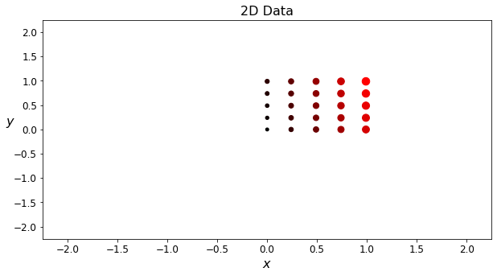

```python
#============
#SIZE OF PLOT
#============
plt.figure(figsize = [10, 5])

#=====================================================================================
#GET ARRAY OF X COORDINATES AND AN ARRAY OF Y COORDINATES FROM ORIGINAL DATA DATAFRAME
#TO PASS THEM TO plt.scatter() METHOD
#=====================================================================================
x = data['x']
y = data['y']

#=======================================
#SET DIFFERENT COLOR FOR EACH DATAPOINTS
#=======================================
#Colors from black to different shades of red (darker intensity to lighter intensity of red)
#Each of the three columns corresponds to an RGB value in the range [0,1].
#Each row represents a datapoint
colors =  np.linspace(start=[0, 0, 0], stop=[1, 0, 0], num=25)

#===========================
#SET SIZE OF EACH DATAPOINTS
#===========================
#size parameter controls the size of the marker used to represent the data point, and is a Numpy array of size (𝑛,)
size = np.linspace(15,90,25)

#==============================
#SET LIMITS OF THE X AND Y AXES
#==============================
#limits parameter is a list that looks like: limits=[xmin,xmax,ymin,ymax], where the values are the limits for the x and y axes.
xmin=-2.25
xmax=2.25
ymin=-2.25
ymax=2.25
limits=[xmin,xmax,ymin,ymax]

#=================
#PLOT INITIAL DATA
#=================
#Plot original datapoints, each with different color and size
plt.scatter(x, y, c=colors, s=size)

#The xlim() and ylim() functions is used to get or set the x-limits and y-limits of the current axes.
plt.xlim(limits[0],limits[1])     # first parameter: minimum number, second parameter: maximum number on x-axis
plt.ylim(limits[2],limits[3])     # first parameter: minimum number, second parameter: maximum number on y-axis

#Label title of the plot
plt.title("2D Data", fontsize=16)
#Label y-axis
plt.ylabel("$y$", fontsize=16, rotation=0)
#Label x-axis
plt.xlabel("$x$", fontsize=16)

plt.show()
```

# Define Data Matrix and Transformation Matrices

The following transformation matrices were defined:

[figure not shown]

```python
#=====================================
# DEFINE DATA MATRIX (ORIGINAL MATRIX)
#=====================================
#Create numpy array X from data dataframe. This is the original matrix
X = np.array(data)

#==================================
# DEFINE 13 TRANSFORMATION MATRICES
#==================================
#Create numpy array of each of the transformation matrices
#AN = np.array[[x1,y1],[x2,y2]]
A1 = np.array([[-1,0],[0,-1]])
A2 = np.array([[0.5,0],[0,1]])
A3 = np.array([
               [round(math.cos(math.pi/4)), round(math.sin(math.pi/4))],
               [round(-(math.sin(math.pi/4))), round(math.cos(math.pi/4))]
            ])
A4 = np.array([[-1,0],[0,1]])
A5 = np.array([[1,0],[0,2.0]])
A6 = np.array([[1,0.5],[0,1]])
A7 = np.array([[1,0],[0.5,1]])
A8 = np.array([[0,-1],[-1,0]])
A9 = np.array([[1,0],[0,0]])
A10 = np.array([[0,0],[0,1]])
A11 = np.array([[1,0],[0,-1]])
A12 = np.array([[0,1],[1,0]])
A13 = np.array([[1,0],[0,1]])
```

# Perform Linear Transformations and Plot Results

Where X_transformed is the data that was read in from the file, A is any one of the thirteen transformation matrices, and X_transformed is the transformed data.

### Identity Matrix on Original Matrix:

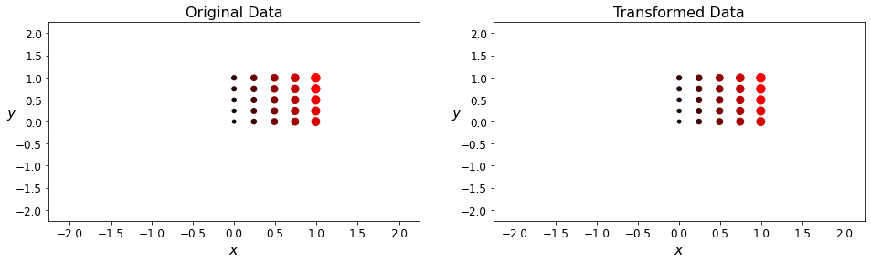

```python
#===============================================
# MATRIX MULTIPLICATION WITH IDENTITY MATRIX 'I'
#===============================================
#Convert data dataframe to numpy array and name it matrix A
A = np.array(data)

#===============
#IDENTITY MATRIX
#===============
#Assigned I to A13. A13 same as an Identity Matrix.
I = A13

#====================================================================================================
#TRANSFORMATION OF ORIGINAL MATRIX USING IDENTITY MATRIX AND PLOTTING ORIGINAL AND TRANSFORMED MATRIX
#====================================================================================================
#Transform original matrix using identity matrix
#using transformMatrixInMatrixMultiplication(original_matrix_np_array, transformation_matrix_np_array) method
#which uses plotTransformedData(original_matrix_df, transformed_matrix_df, colors, size, limits) method in it
transformMatrixInMatrixMultiplication(A,I)
```

### Rotate Original Matrix using Rotation Matrix:

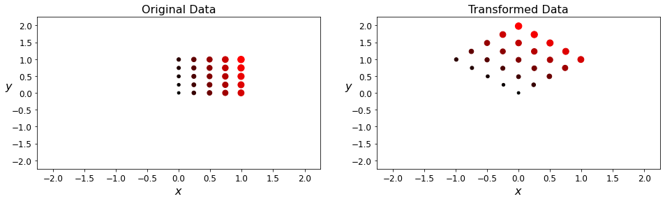

```python
#=============================================
# ROTATE ORIGINAL MATRIX USING ROTATION MATRIX
#=============================================

#===============
#ROTATION MATRIX
#===============
#rotationMatrix is transformation matrix and is equal to A3 matrix.
#In matrix multiplication, it transforms a matrix to a rotated matrix at pi/4 degree (defined in A3) counterclockwise.
rotationMatrix = A3

#===============================================================================
#TRANSFORMATION AND PLOTTING OF ROTATED MATRIX AND COMPARE IT TO ORIGINAL MATRIX
#===============================================================================
#Rotate original matrix to pi/4 degrees counterclockwise using rotation matrix in a matrix multiplication
#using transformMatrixInMatrixMultiplication(original_matrix_np_array, transformation_matrix_np_array) method
#which uses plotTransformedData(original_matrix_df, transformed_matrix_df, colors, size, limits) method in it
transformMatrixInMatrixMultiplication(X,rotationMatrix)   #X is numpy array of "data" and is original matrix
```

### Reflect Original Matrix on X-axis using Reflection Through the X-axis Matrix:

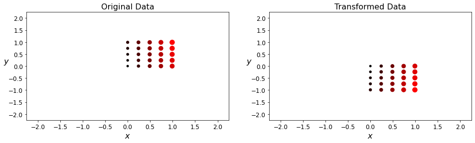

```python
#====================================
#REFLECTION THROUGH THE X-AXIS MATRIX
#====================================
#reflectionThroughXaxisMatrix is transformation matrix and is equal to A11 matrix.
#In matrix multiplication, it transforms a matrix into a reflected matrix on X-axis.
reflectionThroughXaxisMatrix = A11

#=================================================================================================
#TRANSFORMATION AND PLOTTING OF A REFLECTED MATRIX ON THE X-AXIS AND COMPARE IT TO ORIGINAL MATRIX
#=================================================================================================
#Reflect original matrix on X axis using reflection matrix (made for it) in a matrix multiplication
#using transformMatrixInMatrixMultiplication(original_matrix_np_array, transformation_matrix_np_array) method
#which uses plotTransformedData(original_matrix_df, transformed_matrix_df, colors, size, limits) method in it
transformMatrixInMatrixMultiplication(X, reflectionThroughXaxisMatrix)   #X is numpy array of "data" and is original matrix
```

### Reflect Original Matrix on Y-axis using Reflection Through the Y-axis Matrix:

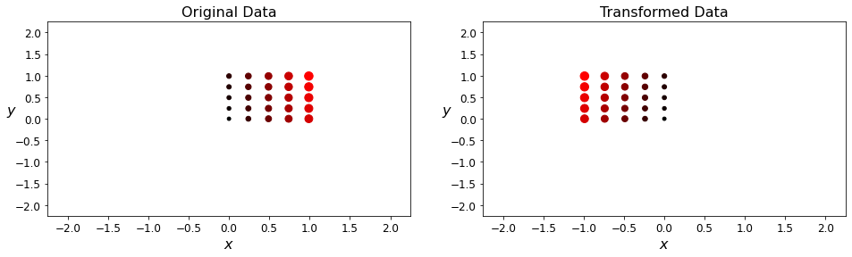

```python
#====================================
#REFLECTION THROUGH THE Y-AXIS MATRIX
#====================================
#reflectionThroughYaxisMatrix is transformation matrix and is equal to A4 matrix.
#In matrix multiplication, it transforms a matrix into a reflected matrix on Y-axis.
reflectionThroughYaxisMatrix = A4

#=================================================================================================
#TRANSFORMATION AND PLOTTING OF A REFLECTED MATRIX ON THE Y-AXIS AND COMPARE IT TO ORIGINAL MATRIX
#=================================================================================================
#Reflect original matrix on Y axis using reflection matrix (made for it) in a matrix multiplication
#using transformMatrixInMatrixMultiplication(original_matrix_np_array, transformation_matrix_np_array) method
#which uses plotTransformedData(original_matrix_df, transformed_matrix_df, colors, size, limits) method in it
transformMatrixInMatrixMultiplication(X, reflectionThroughYaxisMatrix)   #X is numpy array of "data" and is original matrix
```

### Reflect Original Matrix on Y=X axis using Reflection Through the Line Y=X Matrix:

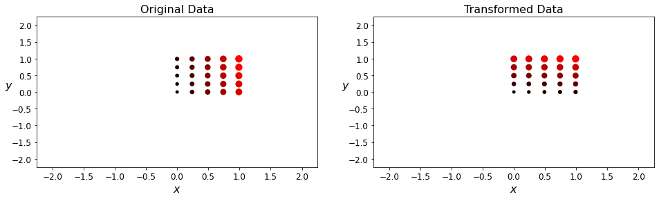

```python
#========================================
#REFLECTION THROUGH THE LINE Y = X MATRIX
#========================================
#reflectionThroughLine_YequalX_matrix is transformation matrix and is equal to A12 matrix.
#In matrix multiplication, it transforms a matrix into a reflected matrix on Y = X axis.
reflectionThroughLine_YequalX_matrix = A12

#=====================================================================================================
#TRANSFORMATION AND PLOTTING OF A REFLECTED MATRIX ON THE Y = X AXIS AND COMPARE IT TO ORIGINAL MATRIX
#=====================================================================================================
#Reflect original matrix on Y=X using reflection matrix (made for it) in a matrix multiplication
#using transformMatrixInMatrixMultiplication(original_matrix_np_array, transformation_matrix_np_array) method
#which uses plotTransformedData(original_matrix_df, transformed_matrix_df, colors, size, limits) method in it
transformMatrixInMatrixMultiplication(X, reflectionThroughLine_YequalX_matrix)   #X is numpy array of "data" and is original matrix
```

### Reflect Original Matrix on Y=-X axis using Reflection Through the Line Y = -X Matrix

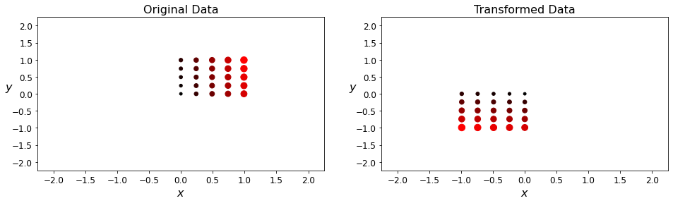

```python
#=========================================
#REFLECTION THROUGH THE LINE Y = -X MATRIX
#=========================================
#reflectionThroughLine_YequalNegX_matrix is transformation matrix and is equal to A8 matrix.
#In matrix multiplication, it transforms a matrix into a reflected matrix on Y = -X.
reflectionThroughLine_YequalNegX_matrix = A8

#======================================================================================================
#TRANSFORMATION AND PLOTTING OF A REFLECTED MATRIX ON THE Y = -X AXIS AND COMPARE IT TO ORIGINAL MATRIX
#======================================================================================================
#Reflect original matrix on Y = -X using reflection matrix (made for it) in a matrix multiplication
#using transformMatrixInMatrixMultiplication(original_matrix_np_array, transformation_matrix_np_array) method
#which uses plotTransformedData(original_matrix_df, transformed_matrix_df, colors, size, limits) method in it
transformMatrixInMatrixMultiplication(X, reflectionThroughLine_YequalNegX_matrix)   #X is numpy array of "data" and is original matrix
```

### Reflect Original Matrix on the Origin using Reflection Through the Origin Matrix:

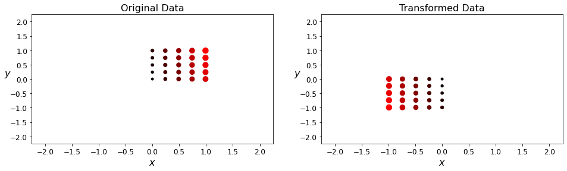

```python
#====================================
#REFLECTION THROUGH THE ORIGIN MATRIX
#====================================
#reflectionThroughOriginMatrix is transformation matrix and is equal to A1 matrix.
#In matrix multiplication, it transforms a matrix into a reflected matrix through the origin.
reflectionThroughOriginMatrix = A1

#=================================================================================================
#TRANSFORMATION AND PLOTTING OF A REFLECTED MATRIX ON THE ORIGIN AND COMPARE IT TO ORIGINAL MATRIX
#=================================================================================================
#Reflect original matrix about the origin using reflection matrix (made for it) in a matrix multiplication
#using transformMatrixInMatrixMultiplication(original_matrix_np_array, transformation_matrix_np_array) method
#which uses plotTransformedData(original_matrix_df, transformed_matrix_df, colors, size, limits) method in it
transformMatrixInMatrixMultiplication(X, reflectionThroughOriginMatrix)   #X is numpy array of "data" and is original matrix
```

### Horizontal Contraction of Original Matrix using Contraction/Expansion Matrix:

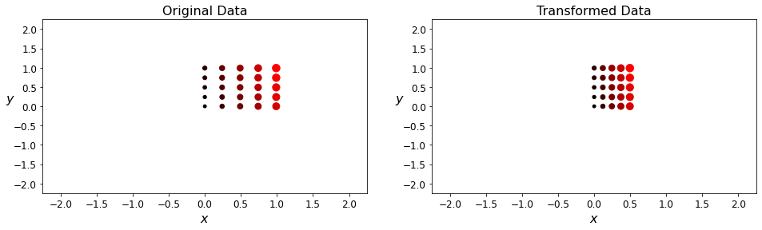

```python
#=======================================
#HORIZONTAL CONTRACTION/EXPANSION MATRIX
#=======================================
#horizontalContractionExpansionMatrix is transformation matrix and is equal to A2
#matrix (which was defined with the scalar multiplication of x component and with scalar value of 0 < scalar value < 1).
#It's contraction due to scalar value which was defined in A2 to be 0 < scalar < 1.
#In matrix multiplication, this horizontally transforms a matrix into a contracted matrix about the X-axis.
horizontalContractionExpansionMatrix = A2

#=====================================================================================================
#TRANSFORMATION AND PLOTTING OF A HORIZONTAL CONTRACTION OF A MATRIX AND COMPARE IT TO ORIGINAL MATRIX
#=====================================================================================================
#Horizontal contraction of original matrix about the X-axis using
#horizontal contraction expansion matrix in a matrix multiplication
#using transformMatrixInMatrixMultiplication(original_matrix_np_array, transformation_matrix_np_array) method
#which uses plotTransformedData(original_matrix_df, transformed_matrix_df, colors, size, limits) method in it
transformMatrixInMatrixMultiplication(X, horizontalContractionExpansionMatrix)  #X is numpy array of "data" and is original matrix
```

### Vertical Expansion of Original Matrix using Contraction/Expansion Matrix:

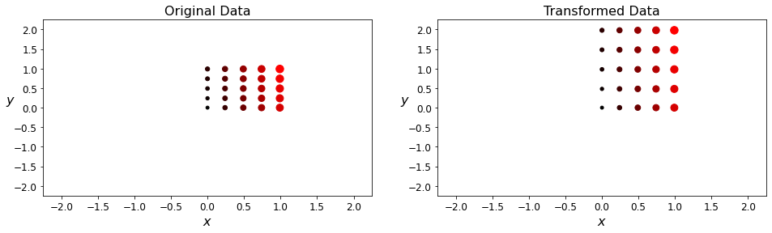

```python
#=====================================
#VERTICAL CONTRACTION/EXPANSION MATRIX
#=====================================
#verticalContractionExpansionMatrix is transformation matrix and is equal to A5
#matrix (which was defined with the scalar multiplication of y component and with scalar value > 1).
#It's expansion due to scalar value which was defined in A5 to be greater than 1.
#In matrix multiplication, this vertically transforms a matrix into an expanded matrix about the Y-axis.
verticalContractionExpansionMatrix = A5

#=============================================================================================================
#TRANSFORMATION AND PLOTTING OF A VERTICAL EXPANSION (ON Y-AXIS) OF A MATRIX AND COMPARE IT TO ORIGINAL MATRIX
#=============================================================================================================
#Verical expansion of original matrix about the Y-axis using
#vertical expansion matrix in a matrix multiplication
#using transformMatrixInMatrixMultiplication(original_matrix_np_array, transformation_matrix_np_array) method
#which uses plotTransformedData(original_matrix_df, transformed_matrix_df, colors, size, limits) method in it
transformMatrixInMatrixMultiplication(X, verticalContractionExpansionMatrix)  #X is numpy array of "data" and is original matrix
```

### Horizontal Shearing of an Original Matrix using the Horizontal Shear Matrix:

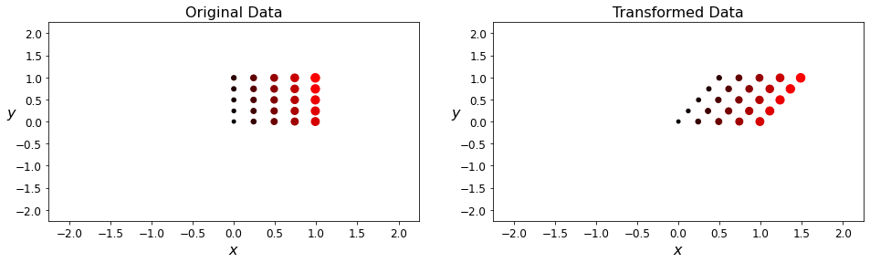

```python
#=======================
#HORIZONTAL SHEAR MATRIX
#=======================
#horizontalShearMatrix is transformation matrix and is same as A7 matrix
#In matrix multiplication, it horizontally shears a matrix on X-axis.
horizontalShearMatrix = A7

#======================================================================================================
#TRANSFORMATION AND PLOTTING OF A HORIZONTAL SHEARED MATRIX ON X-AXIS AND COMPARE IT TO ORIGINAL MATRIX
#======================================================================================================
#Horizontal shear of original matrix about the X-axis using
#horizontal shear matrix in a matrix multiplication
#using transformMatrixInMatrixMultiplication(original_matrix_np_array, transformation_matrix_np_array) method
#which uses plotTransformedData(original_matrix_df, transformed_matrix_df, colors, size, limits) method in it
transformMatrixInMatrixMultiplication(X, horizontalShearMatrix)  #X is numpy array of "data" and is original matrix
```

### Vertical Shearing of an Original Matrix using the Vertical Shear Matrix:

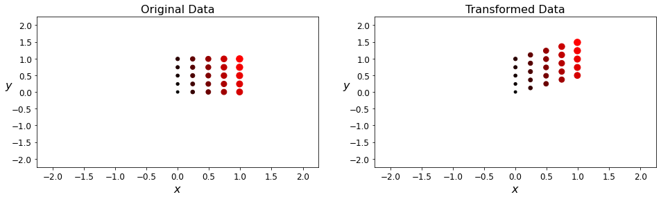

```python
#=======================
#VERTICAL SHEAR MATRIX
#=======================
#verticalShearMatrix is transformation matrix and is same as A6 matrix
#In matrix multiplication, it vertically shears a matrix on Y-axis.
verticalShearMatrix = A6

#====================================================================================================
#TRANSFORMATION AND PLOTTING OF A VERTICAL SHEARED MATRIX ON Y-AXIS AND COMPARE IT TO ORIGINAL MATRIX
#====================================================================================================
#Vertical shear of original matrix about the Y-axis using
#vertical shear matrix in a matrix multiplication
#using transformMatrixInMatrixMultiplication(original_matrix_np_array, transformation_matrix_np_array) method
#which uses plotTransformedData(original_matrix_df, transformed_matrix_df, colors, size, limits) method in it
transformMatrixInMatrixMultiplication(X, verticalShearMatrix)  #X is numpy array of "data" and is original matrix
```

### Projecting Original Matrix onto X-axis using Projection on X-axis Matrix:

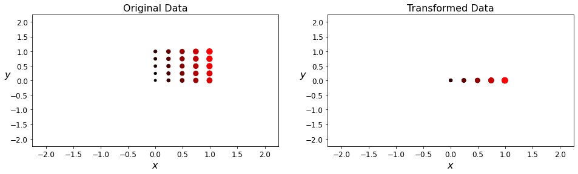

```python
#=============================
#PROJECTION ONTO X-AXIS MATRIX
#=============================
#projectionOntoXaxisMatrix is transformation matrix and is equal to A9 matrix
#In matrix multiplication, it projects matrix onto X-axis.
projectionOntoXaxisMatrix = A9

#=================================================================================================
#TRANSFORMATION AND PLOTTING OF THE PROJECTED MATRIX ONTO X-AXIS AND COMPARE IT TO ORIGINAL MATRIX
#=================================================================================================
#Project original matrix onto the X-axis using
#projection onto X-axis matrix in a matrix multiplication
#using transformMatrixInMatrixMultiplication(original_matrix_np_array, transformation_matrix_np_array) method
#which uses plotTransformedData(original_matrix_df, transformed_matrix_df, colors, size, limits) method in it
transformMatrixInMatrixMultiplication(X, projectionOntoXaxisMatrix)  #X is numpy array of "data" and is original matrix
```

### Projecting Original Matrix onto Y-axis using Projection on Y-axis Matrix:

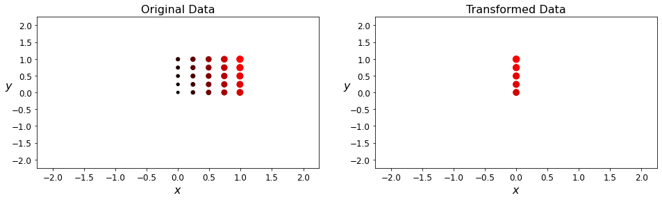

```python
#=============================
#PROJECTION ONTO Y-AXIS MATRIX
#=============================
#projectionOntoYaxisMatrix is transformation matrix and is equal to A10 matrix
#In matrix multiplication, it projects matrix onto Y-axis.
projectionOntoYaxisMatrix = A10

#=================================================================================================
#TRANSFORMATION AND PLOTTING OF THE PROJECTED MATRIX ONTO Y-AXIS AND COMPARE IT TO ORIGINAL MATRIX
#=================================================================================================
#Project original matrix onto the Y-axis using
#projection onto Y-axis matrix in a matrix multiplication
#using transformMatrixInMatrixMultiplication(original_matrix_np_array, transformation_matrix_np_array) method
#which uses plotTransformedData(original_matrix_df, transformed_matrix_df, colors, size, limits) method in it
transformMatrixInMatrixMultiplication(X, projectionOntoYaxisMatrix)  #X is numpy array of "data" and is original matrix
```